# Modeling Swire Coca Cola

#### Average Downtime by Production Location

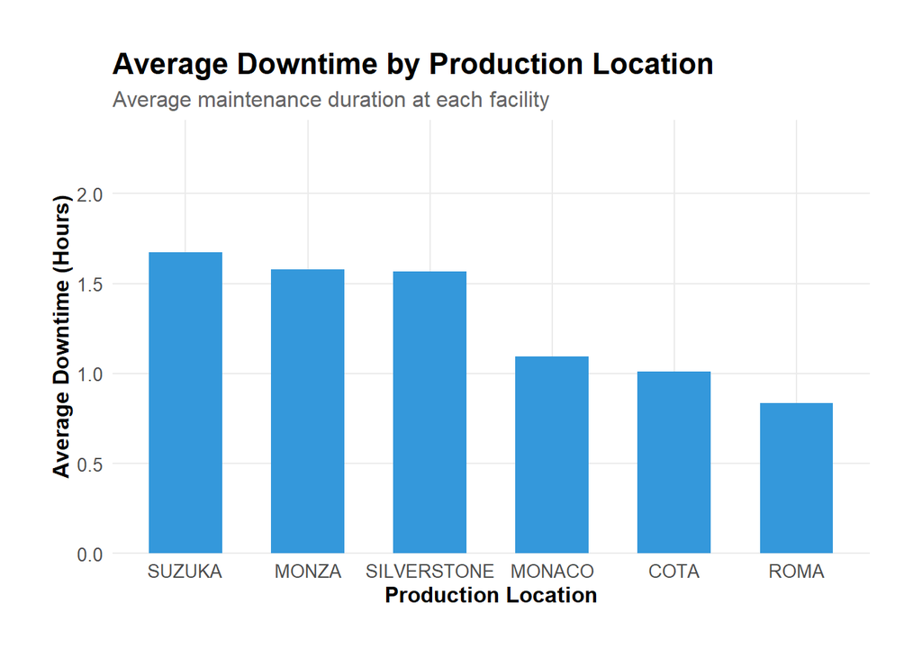

```r
# Create summary with cleaner statistics
downtime_summary <- data %>%
  group_by(PRODUCTION_LOCATION) %>%
  summarise(
    avg_downtime_hours = mean(ACTUAL_WORK_IN_MINUTES, na.rm = TRUE)/60,
    total_events = n(),
    median_downtime_hours = median(ACTUAL_WORK_IN_MINUTES, na.rm = TRUE)/60
  ) %>%
  arrange(desc(avg_downtime_hours))

# Create improved visualization
ggplot(downtime_summary,
       aes(x = reorder(PRODUCTION_LOCATION, -avg_downtime_hours),
           y = avg_downtime_hours)) +
  # Main bars
  geom_bar(stat = "identity",
           fill = "#3498db",
           width = 0.6) +
  # Add labels on top of bars
  geom_text(aes(label = sprintf("%.1f hrs\n%s events",
                               avg_downtime_hours,
                               format(total_events, big.mark = ","))),
            position = position_stack(vjust = -0.2),
            size = 3.5) +
  # Labels and theme
  labs(
    title = "Average Downtime by Production Location",
    subtitle = "Average maintenance duration at each facility",
    x = "Production Location",
    y = "Average Downtime (Hours)"
  ) +
  theme_minimal() +
  theme(
    plot.title = element_text(size = 16, face = "bold"),
    plot.subtitle = element_text(size = 12, color = "grey40"),
    axis.title = element_text(size = 12, face = "bold"),
    axis.text = element_text(size = 10),
    axis.text.x = element_text(angle = 0),
    legend.position = "right",
    panel.grid.minor = element_blank(),
    plot.margin = unit(c(1, 1, 1, 1), "cm")  # Proper margin specification
  ) +
  # Adjust y-axis for better proportion
  scale_y_continuous(
    expand = expansion(mult = c(0, 0.2)),
    limits = c(0, max(downtime_summary$avg_downtime_hours) * 1.2)
  )
```

```r
# Print summary statistics
print("Downtime Statistics by Location:")
```

```
[1] "Downtime Statistics by Location:"
```

```r
print(downtime_summary %>%
        mutate_if(is.numeric, round, 2) %>%
        arrange(desc(avg_downtime_hours)))
```

```
# A tibble: 6 × 4
  PRODUCTION_LOCATION avg_downtime_hours total_events median_downtime_hours
  <chr>                            <dbl>        <dbl>                 <dbl>
1 SUZUKA                            1.67       290975                  1
2 MONZA                             1.58       225279                  0.73
3 SILVERSTONE                       1.57       630903                  0.9
4 MONACO                            1.1         84694                  0.06
5 COTA                              1.01       116303                  0.52
6 ROMA                              0.84        79110                  0.3
```

The Average Downtime by Production Location visualization reveals significant variations in maintenance efficiency across facilities. Suzuka leads with the highest average downtime of approximately 1.7 hours per maintenance event, closely followed by Monza and Silverstone at about 1.6 hours each. In contrast, Roma shows the best performance with average downtimes of less than 1 hour per event. This difference could be attributed to various factors such as equipment complexity, maintenance team expertise, or the nature of issues being addressed at each location. The consistently lower downtime at Roma might offer best practices that could be valuable for other locations to study and potentially implement.

### 5. Machine Failure Prediction by Equipment Age

#### Equipment Age vs. Downtime Analysis

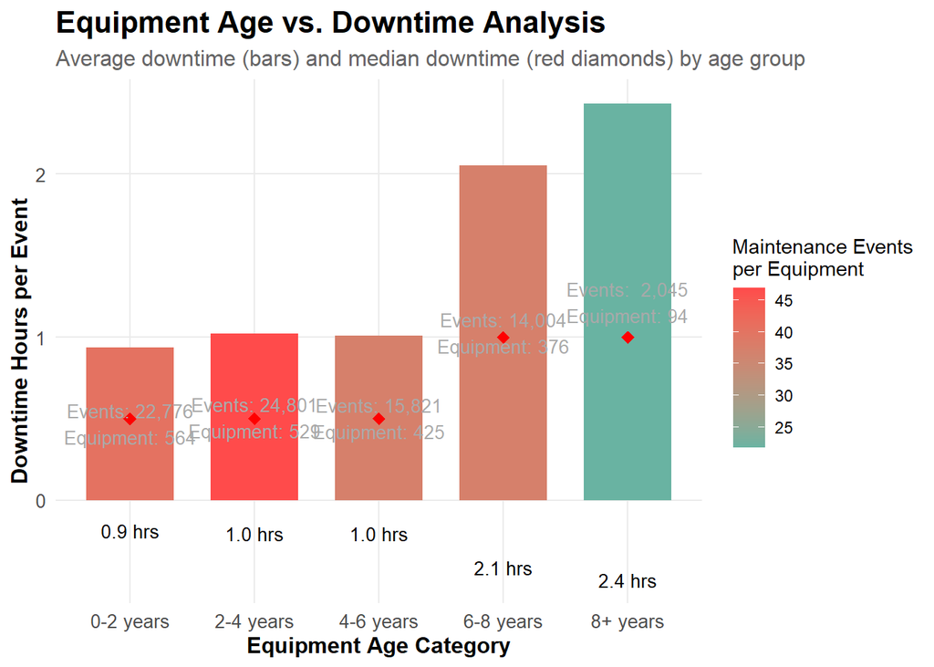

```r
# Calculate equipment age and create analysis
equipment_analysis <- data %>%
  mutate(
    equipment_age = as.numeric(difftime(
      as.Date(EXECUTION_START_DATE),
      as.Date(EQUIP_START_UP_DATE),
      units = "days"
    ))/365,
    age_category = case_when(
      equipment_age <= 2 ~ "0-2 years",
      equipment_age <= 4 ~ "2-4 years",
      equipment_age <= 6 ~ "4-6 years",
      equipment_age <= 8 ~ "6-8 years",
      TRUE ~ "8+ years"
    ),
    age_category = factor(age_category,
                         levels = c("0-2 years", "2-4 years",
                                  "4-6 years", "6-8 years", "8+ years"))
  ) %>%
  filter(!is.na(equipment_age))

# Create summary statistics
age_summary <- equipment_analysis %>%
  group_by(age_category) %>%
  summarise(
    avg_downtime = mean(ACTUAL_WORK_IN_MINUTES, na.rm = TRUE)/60,
    median_downtime = median(ACTUAL_WORK_IN_MINUTES, na.rm = TRUE)/60,
    total_maintenance = n(),
    unique_equipment = n_distinct(EQUIPMENT_ID),
    maintenance_per_equipment = total_maintenance/unique_equipment
  ) %>%
  mutate(
    label = sprintf("Events: %s\nEquipment: %d",
                   format(total_maintenance, big.mark = ","),
                   unique_equipment)
  )

# Create simplified visualization
ggplot(age_summary) +
  # Main bars for average downtime
  geom_bar(aes(x = age_category, y = avg_downtime, fill = maintenance_per_equipment),
           stat = "identity", width = 0.7) +
  # Add median line
  geom_point(aes(x = age_category, y = median_downtime),
             color = "red", size = 3, shape = 18) +
  # Add labels
  geom_text(aes(x = age_category,
                y = avg_downtime,
                label = sprintf("%.1f hrs", avg_downtime)),
            position = position_stack(vjust = -0.2),
            size = 3.5) +
  geom_text(aes(x = age_category,
                y = avg_downtime/2,
                label = label),
            size = 3.5,
            color = "darkgrey") +
  # Customize colors
  scale_fill_gradient(
    low = "#69b3a2",
    high = "#FF4B4B",
    name = "Maintenance Events\nper Equipment"
  ) +
  # Labels and theme
  labs(
    title = "Equipment Age vs. Downtime Analysis",
    subtitle = "Average downtime (bars) and median downtime (red diamonds) by age group",
    x = "Equipment Age Category",
    y = "Downtime Hours per Event"
  ) +
  theme_minimal() +
  theme(
    plot.title = element_text(size = 16, face = "bold"),
    plot.subtitle = element_text(size = 12, color = "grey40"),
    axis.title = element_text(size = 12, face = "bold"),
    axis.text = element_text(size = 10),
    axis.text.x = element_text(angle = 0),
    legend.position = "right",
    panel.grid.minor = element_blank()
  )
```

```r
# Print detailed statistics
print("Age Group Statistics:")
```

```
[1] "Age Group Statistics:"
```

```r
print(age_summary %>%
        select(-label) %>%
        arrange(age_category))
```

```
# A tibble: 5 × 6
  age_category avg_downtime median_downtime total_maintenance unique_equipment
  <fct>               <dbl>           <dbl>             <int>            <int>
1 0-2 years           0.938             0.5             22776              564
2 2-4 years           1.02              0.5             24801              529
3 4-6 years           1.01              0.5             15821              425
4 6-8 years           2.05              1               14004              376
5 8+ years            2.43              1                2045               94
# ℹ 1 more variable: maintenance_per_equipment <dbl>
```

The Equipment Age vs. Downtime Analysis, there’s a clear trend showing that maintenance demands increase with equipment age. The newest equipment (0-2 years) shows the lowest average downtime at 0.9 hours per event, while equipment over 8 years old requires significantly more maintenance time, averaging 2.4 hours per event. It’s particularly noteworthy that there’s a substantial jump in downtime duration when equipment reaches the 6-8 year mark, where average maintenance time doubles to 2.1 hours compared to younger equipment. This suggests a critical aging threshold where maintenance becomes more complex and time-consuming.